# Balancing an Inverted Pendulum **(RL)**

Name: Goh Pin Pin Isaac & Shane Axel Raj  
Admin Number: P2317623 & P2210982  
Class: DAAA/FT/2B/23

# Project Objective

- `Apply torque on the free end to swing it into an upright position.`

# Questions

- how to systematically optimise your solutions
- What hyperparameters can you tune?
- How many trials does it need?
- How do you conclusively demonstrate your so-called “best setup” to be the best?
- What is criteria to use (fastest learning | most stable learning | others)

# Background

Training an AI to **balance a pendulum**, known as the inverted pendulum problem, serves as a foundational challenge in control theory and **reinforcement learning** with broad practical applications.

The principles and techniques developed for this task are critical in robotics, such as for self-balancing robots and robotic manipulators, as well as in aerospace engineering for stabilizing rockets and maintaining satellite orientation. Additionally, these concepts are applied in transportation systems, including self-driving cars and motorcycles, and in active suspension systems for vehicles to enhance stability and safety.

Beyond these areas, the balancing algorithms are also utilized in renewable energy systems, like optimizing wind turbine control and stabilizing wave energy converters. In healthcare, they contribute to the development of advanced prosthetics and rehabilitation robotics, improving patient support and mobility. Moreover, entertainment and gaming industries leverage these techniques for creating more immersive virtual and augmented reality experiences, while camera gimbals use them to ensure smooth footage in dynamic conditions. These diverse applications showcase the far-reaching impact of mastering the balancing challenge in AI and control systems.

# Gym Info

The inverted pendulum swingup problem is based on the classic problem in control theory. The system consists of a pendulum attached at one end to a fixed point, and the other end being free. The pendulum starts in a random position and the goal is to apply torque on the free end to swing it into an upright position, with its center of gravity right above the fixed point.

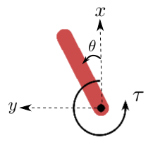

- `x-y`: cartesian coordinates of the pendulum’s end in meters.
- `theta` : angle in radians.
- `tau`: torque in N m. Defined as positive counter-clockwise.

#### **Observation Space**

| Observation | Min | Max |
| --- | --- | --- |
| x = cos(theta) | -1.0 | 1.0 |
| y = sin(angle) | -1.0 | 1.0 |
| Angular Velocity | -8.0 | 8.0 |

#### **Continuous Actions**

| Action | Min | Max |
| --- | --- | --- |
| Torque | -2.0 | 2.0 |

#### **Rewards**

- $r = -(theta2 + 0.1 * theta_dt2 + 0.001 * torque2)$

#### **Starting State**

- The starting state is a random angle in [-$π$, $π$] and a random angular velocity in [-1,1].

```python
# Importing Modules
from tqdm import tqdm
import numpy as np
import pandas as pd
import os
import time
from IPython import display
import imageio
from scipy.linalg import sqrtm
import random
from collections import deque, namedtuple
from IPython import display as ipythondisplay
from pyvirtualdisplay.display import Display
from matplotlib import animation, rc
import IPython.display as ipd
from sklearn.model_selection import ParameterSampler
import itertools


# Plotting
import matplotlib.pyplot as plt
from matplotlib.gridspec import GridSpec
import seaborn as sns
import visualkeras

# Gym
import gym

# Tensorflow
import tensorflow as tf
from keras.layers import Dense, Input, Activation, BatchNormalization
from keras.optimizers import Adam
from keras import Model
```

```python
# use CPU
os.environ['CUDA_VISIBLE_DEVICES'] = '-1'
```

```python
# Suppress TensorFlow logging
tf.keras.utils.disable_interactive_logging()
```

```python
sns.set(style="ticks")
```

```python
plt.style.use('ggplot')
```

# **Exploratory Data Analysis**

```python
env = gym.make('Pendulum-v0')
print(f"Observation Space: {env.observation_space.shape[0]}")
```

```
Observation Space: 3
```

State Variables:

- cos(theta): Cosine of the angle
- sin(theta): Sine of the angle
- theta_dot: Angular velocity

```python
print(f"Action space: {env.action_space}")
print(f"Observation space: {env.observation_space}")
print(f"Observation space high: {env.observation_space.high}")
print(f"Observation space low: {env.observation_space.low}")
print("\nSampling Enviroment:")
# Sample a random action and state
initial_state = env.reset()
print(f"Initial state: {initial_state}")

action = env.action_space.sample()
print(f"Sampled action: {action}")

next_state, reward, done, _ = env.step(action)
print(f"Next state: {next_state}, Reward: {reward}, Done: {done}")
```

```
Action space: Box(-2.0, 2.0, (1,), float32)
Observation space: Box(-8.0, 8.0, (3,), float32)
Observation space high: [1. 1. 8.]
Observation space low: [-1. -1. -8.]

Sampling Enviroment:
Initial state: [-0.8972807  -0.44146047  0.20366555]
Sampled action: [0.15982237]
Next state: [-0.89955228 -0.43681311 -0.10345645], Reward: -7.20999955536354, Done: False
```

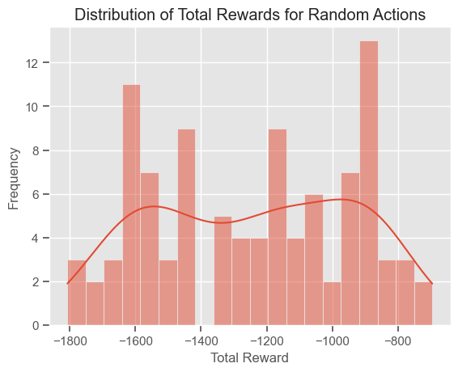

```python
def analyze_rewards(env, num_episodes=100):
    rewards = []
    for _ in range(num_episodes):
        state = env.reset()
        episode_reward = 0
        for _ in range(200):  # Limit the length of each episode
            action = env.action_space.sample()
            next_state, reward, done, _ = env.step(action)
            episode_reward += reward
            if done:
                break
        rewards.append(episode_reward)
    return rewards

rewards = analyze_rewards(env)
sns.histplot(rewards, bins=20, kde=True)
plt.xlabel("Total Reward")
plt.ylabel("Frequency")
plt.title("Distribution of Total Rewards for Random Actions")
plt.show()
```

**Observation:**

- There isn't a visible trend of the score.

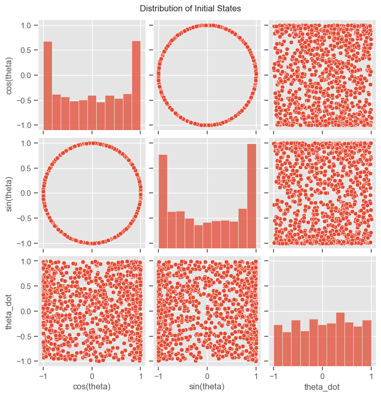

```python
def sample_states(env, num_samples=1000):
    states = []
    for _ in range(num_samples):
        state = env.reset()
        states.append(state)
    return np.array(states)

states = sample_states(env)
sns.pairplot(pd.DataFrame(states, columns=["cos(theta)", "sin(theta)", "theta_dot"]))
plt.suptitle("Distribution of Initial States", y=1.02)
plt.show()
```

### **Observation**

- Initial State Distribution:
  - cos(theta) and sin(theta): These form a perfect circle when plotted against each other, indicating that the initial angle is uniformly distributed across all possible angles (0 to 2π radians or 0 to 360 degrees).
  - theta_dot: The angular velocity seems to be initialized with a uniform distribution between approximately -1 and 1, suggesting the pendulum can start with any speed within this range, in either direction.
- Independence:
  - The scatter plots between theta_dot and cos(theta) or sin(theta) show a uniform rectangular distribution, indicating that the initial angle and angular velocity are independently sampled.
- Constraints:
  - The cos(theta) and sin(theta) values are constrained between -1 and 1, as expected for trigonometric functions.
  - theta_dot appears to be constrained between approximately -1 and 1, suggesting a maximum `initial` angular velocity in either direction.

# **Model Training**

## **Types of Architecture**

- `Value-based methods:`

These algorithms focus on learning the value function, which estimates the expected return from a state or state-action pair.  
DQN and NoisyDQN fall into this category as they both aim to approximate the Q-value function. - **DQN (Deep Q-Network)** - **NoisyDQN**

- `Policy-based methods:`

These algorithms directly optimize the policy without necessarily learning a value function.  
PPO is a policy-based method that uses trust region optimization to improve the policy. - **PPO (Proximal Policy Optimization)**

- `Actor-Critic methods:`

These algorithms combine elements of both value-based and policy-based approaches.  
They typically have two components: an "actor" that learns the policy and a "critic" that learns the value function.  
Both SAC and DDPG are actor-critic methods. - **SAC (Soft Actor-Critic)** - **DDPG (Deep Deterministic Policy Gradient)**

> However, we will only be eploring the `DQN`, `NoisyDQN` & `DDPG`

## **HyperParameters**

- ***Network Architecture Parameters***
  - `Intermediate Size`
    - **Description:** The size of the intermediate layers in the neural network.
    - **Purpose:** Specifies the number of neurons in the hidden layers of the neural network, affecting the capacity and performance of the model.
- ***Training Parameters***
  - `Learning Rate`
    - **Description:** The learning rate for the network.
    - **Purpose:** Controls how much the network's weights are adjusted with respect to the gradient during training.
  - `Gamma`
    - **Description:** The discount factor for future rewards.
    - **Purpose:** Determines the importance of future rewards compared to immediate rewards. A value closer to 1 makes the agent consider long-term rewards more.
  - `Batch Size`
    - **Description:** The number of samples used in one training iteration.
    - **Purpose:** Defines how many experiences are drawn from the replay memory to compute the gradient, impacting the stability and speed of learning.
  - `Replay_memory Size`
    - **Description:** The maximum size of the replay memory.
    - **Purpose:** Limits the number of past experiences stored for training the agent. Larger sizes can provide more diverse training data.
  - `Min Replay Memory Size`
    - **Description:** The minimum size of replay memory before training starts.
    - **Purpose:** Ensures that a sufficient amount of experiences is available in the replay memory to sample from, which helps in stabilizing training.

## **Leanring Process (Graphs)**

- `Average Q-value Over Step:` Represents the estimated value of actions.
- `Episode Return Over Time:` Shows the total reward obtained in each episode.
- `Gradient Over Step:` Shows how much the model's parameters are changing at each step.
- `Loss Over Step:` Indicates the error in the model's predictions.

```python
# Initialize the environment
EnvName = 'Pendulum-v0'

# Hyperparameters
IntermediateSize = 64
Epsilon = 0.1
ShowEvery = 10
InputShape = 3
NActions = 40
```

#### **Common Functions**

```python
def PendulumActionConverter(A, NActions=NActions):
    ActualTorque = (A / NActions - 0.5) * 4
    return ActualTorque

def PendulumInverseActionConverter(A, NActions=NActions):
    ActualA = round((A + 2) * (NActions - 1) / 4)
    return(ActualA)

def OneEpisode(agent):
    env = gym.make(f'{EnvName}')
    S = env.reset()
    ListOfRewards = []
    Done = False
    step_count = 0

    while not Done:
        Q = agent.Main(S.reshape(-1, S.shape[0]))
        if np.random.rand() < Epsilon:
            AStep = env.action_space.sample()
            A = PendulumInverseActionConverter(AStep[0])
        else:
            A = np.argmax(Q)
            A = PendulumActionConverter(A)
            AStep = np.array([A])
            A = PendulumInverseActionConverter(A)

        SNext, R, Done, Info = env.step(AStep)
        agent.UpdateReplayMemory((S, A, R, SNext, Done))
        agent.Train(Done)
        ListOfRewards.append(R)
        S = SNext
        step_count += 1

    total_reward = np.sum(ListOfRewards)
    agent.record_episode_reward(total_reward)
    print(f'Finished! Return: {total_reward}')
    env.close()
    return total_reward

def plot_learning_curve(agent):
    plt.figure(figsize=(10, 5))
    plt.plot(agent.return_history)
    plt.title('Learning Curve')
    plt.xlabel('Episode')
    plt.ylabel('Total Reward')
    plt.show()

def create_gif(agent):
    env = gym.make(f'{EnvName}')
    S = env.reset()
    ListOfRewards = []
    Done = False
    frames = []

    while not Done:
        Q = agent.Main(S.reshape(-1, S.shape[0]))
        if np.random.rand() < Epsilon:
            AStep = env.action_space.sample()
            A = PendulumInverseActionConverter(AStep[0])
        else:
            A = np.argmax(Q)
            A = PendulumActionConverter(A)
            AStep = np.array([A])
            A = PendulumInverseActionConverter(A)

        SNext, R, Done, Info = env.step(AStep)

        # Capture the frame after stepping
        frame = env.render(mode='rgb_array')
        frames.append(frame)

        agent.UpdateReplayMemory((S, A, R, SNext, Done))
        agent.Train(Done)
        ListOfRewards.append(R)
        S = SNext

    env.close()

    # Save frames as gif
    imageio.mimsave(f'./CA2-Output/RL-Training/{agent.name}_final.gif', frames, fps=30)
```

# **Baseline (`Deep Q-Network`)**

DQN is a reinforcement learning algorithm that combines Q-learning with deep neural networks to handle high-dimensional state spaces. It approximates the Q-value function using a neural network, which predicts the expected reward for each action given a state.

## **Key Components of DQN**

- **Q-Network**
  - **Input Layer**: The current state of the environment.
  - **Hidden Layers**: Several layers to extract features from the state.
  - **Output Layer**: Q-values for each possible action.
- **Experience Replay**
  - **Replay Buffer**: Stores agent's experiences `(s, a, r, s')`.
  - **Batch Training**: Random mini-batches sampled from the buffer for training.
- **Target Network**
  - **Purpose**: Provides stable Q-value targets.
  - **Target Update**: Updated periodically with the Q-Network's weights.
- **Bellman Equation and Loss Function**
  - **Q-learning Update Rule**: $y = r + \gamma \max_{a'} Q(s', a'; \theta^-)$
  - **Loss Function**: $L(\theta) = \mathbb{E} \left[ (y - Q(s, a; \theta))^2 \right]$

```python
class DQN:
    def __init__(self,
                 InputShape = 3,
                 NActions = 2,
                 Gamma = 1,
                 ReplayMemorySize = 10000,
                 MinReplayMemory = 1000,
                 UpdateTargetEveryThisEpisodes = 1,
                 IntermediateSize = 64,
                 BatchSize = 32):
        self.name = 'Baseline'
        self.avg_return = 0

        # Hyperparameters. #
        self.InputShape = InputShape
        self.NActions = NActions
        self.Gamma = Gamma
        self.ReplayMemorySize = ReplayMemorySize
        self.MinReplayMemory = MinReplayMemory
        self.UpdateTargetEveryThisEpisodes = UpdateTargetEveryThisEpisodes
        self.IntermediateSize = IntermediateSize
        self.BatchSize = BatchSize
        self.return_history = []
        self.loss_history = []
        self.q_value_history = []
        self.gradient_history = []

        # Main model. #
        self.Main = self.CreateModel('Main')
        self.Optimiser = Adam()

        # Target model. #
        self.Target = self.CreateModel('Target')
        self.Target.set_weights(self.Main.get_weights())

        # Replay memory. #
        self.ReplayMemory = deque(maxlen = ReplayMemorySize)

        # Target network update counter. #
        self.TargetUpdateCounter = 0

    def record_episode_reward(self, episode_reward):
        self.return_history.append(episode_reward)

    def plot_magnitudes(self):
        # Create a DataFrame from our data
        df = pd.DataFrame({
            'Step': range(len(self.loss_history)),
            'Loss': self.loss_history,
            'Q-value': self.q_value_history,
            'Gradient': self.gradient_history
        })

        # Set up the plot style
        sns.set_style("whitegrid")
        sns.set_palette("deep")

        # Create the plot
        fig, axs = plt.subplots(2, 2, figsize=(20, 16))
        fig.suptitle('Learning Progress', fontsize=20)

        # Plot Loss, Q-value, and Gradient
        sns.lineplot(data=df, x='Step', y='Gradient', ax=axs[0, 0], color='blue')
        axs[0, 0].set_title('Gradient Over Step', fontsize=16)

        # Plot Loss separately
        sns.lineplot(data=df, x='Step', y='Loss', ax=axs[0, 1], color='red')
        axs[0, 1].set_title('Loss Over Step', fontsize=16)

        # Plot Q-value separately
        sns.lineplot(data=df, x='Step', y='Q-value', ax=axs[1, 0], color='green')
        axs[1, 0].set_title('Average Q-value Over Step', fontsize=16)

        # Plot Episode Reward
        return_df = pd.DataFrame({
            'Episode': range(len(self.return_history)),
            'Return': self.return_history
        })
        sns.lineplot(data=return_df, x='Episode', y='Return', ax=axs[1, 1], color='orange')
        axs[1, 1].set_title('Episode Return Over Time', fontsize=16)

        # Adjust layout and display
        plt.tight_layout()
        plt.show()

    def CreateModel(self, Type):
        inputs = Input(shape = (self.InputShape), name = 'Input')
        x = Dense(self.IntermediateSize, activation = 'relu', name = '1stHiddenLayer')(inputs)
        x = Dense(self.IntermediateSize, activation = 'relu', name = '2ndHiddenLayer')(x)
        outputs = Dense(self.NActions, activation = 'linear', name = 'Output')(x)

        NN = Model(inputs, outputs, name = f'{Type}')
        NN.summary()

        return NN

    def UpdateReplayMemory(self, Information): # Information = (S, A, R, SNext, Done)
        self.ReplayMemory.append(Information)

    def Train(self, EndOfEpisode):
        if len(self.ReplayMemory) < self.MinReplayMemory:
            return

        # Get batch of data for training. #
        TrainingData = random.sample(self.ReplayMemory, self.BatchSize)

        # Get states from training data, then get corresponding Q values. #
        ListOfS = np.array([element[0] for element in TrainingData])
        ListOfQ = np.array(self.Main(ListOfS))

        # Get future states from training data, then get corresponding Q values. #
        ListOfSNext = np.array([element[3] for element in TrainingData])
        ListOfQNext = self.Target(ListOfSNext)

        # Build actual training data for neural network. #
        X = []
        Y = []
        for index, (S, A, R, SNext, Done) in enumerate(TrainingData):
            if not Done:
                MaxQNext = np.max(ListOfQNext[index])
                QNext = R + self.Gamma * MaxQNext
            else:
                QNext = R
            Q = ListOfQ[index]
            Q[A] = QNext

            X.append(S)
            Y.append(Q)

        # Train model using tf.GradientTape(), defined below.
        Loss, Predictions, Grad = self.GTfit(X, Y)
        self.loss_history.append(float(Loss))
        self.q_value_history.append(float(tf.reduce_mean(Predictions)))
        self.gradient_history.append(float(tf.linalg.global_norm(Grad)))

        # Update target network every episode. #
        if EndOfEpisode:
            self.TargetUpdateCounter += 1

        # Update target if counter is full. #
        if self.TargetUpdateCounter >= self.UpdateTargetEveryThisEpisodes:
            self.Target.set_weights(self.Main.get_weights())
            self.TargetUpdateCounter = 0

    @tf.function
    def GTfit(self, X, Y):
        with tf.GradientTape() as tape:
            Predictions = self.Main(tf.convert_to_tensor(X), training=True)
            Loss = tf.math.reduce_mean(tf.math.square(tf.convert_to_tensor(Y) - Predictions))
        Grad = tape.gradient(Loss, self.Main.trainable_variables)
        self.Optimiser.apply_gradients(zip(Grad, self.Main.trainable_variables))
        return Loss, Predictions, Grad
```

```
Trying configuration 1/5:
Params: HyperParams(intermediate_size=32, learning_rate=0.01, gamma=0.95, batch_size=128, replay_memory_size=100000, min_replay_memory=10000, update_target_every=20)
Episode 0 Finished! Return: -525.0360894627848
Finished! Return: -1299.2542910818509
Finished! Return: -1622.467439722361
Finished! Return: -1136.2502360052551
Finished! Return: -1472.5103013836701
Finished! Return: -1344.2035456192575
Finished! Return: -1676.47023576628
Finished! Return: -1653.5210203046554
Finished! Return: -1219.2038607084967
Finished! Return: -1497.7320863095406
Episode 10 Finished! Return: -1587.329661134114
Finished! Return: -1678.4182451083836
Finished! Return: -1642.4789444411167
Finished! Return: -1566.0281491897638
Finished! Return: -1704.8814439592488
Finished! Return: -1684.6646807009672
Finished! Return: -1290.6590427974147
Finished! Return: -1438.93552466469
Finished! Return: -1667.5335531544763
Finished! Return: -1203.1291214625196
Episode 20 Finished! Return: -1569.3019970306636
Finished! Return: -1672.5372591303765
Finished! Return: -1353.221822412975
Finished! Return: -1560.5290873023414
Finished! Return: -1537.4865585445777
Finished! Return: -1508.599087839688
Finished! Return: -1676.8974802538905
Finished! Return: -706.0724451794505
Finished! Return: -1356.1803011249676
Finished! Return: -1641.8248243376615
Episode 30 Finished! Return: -1339.3715475065542
Finished! Return: -1150.1209241569798
Finished! Return: -1667.2406230965912
Finished! Return: -395.6232119433447
Finished! Return: -1684.667662009703
Finished! Return: -1679.2416614703282
Finished! Return: -1123.7158745771724
Finished! Return: -1679.1352388407072
```

[output cut: 870 more lines]

```
Finished! Return: -254.44375685188731
Finished! Return: -253.19837936124097
Finished! Return: -402.6067582154934
Finished! Return: -255.38821697946952
Finished! Return: -505.2226357153006
Episode 140 Finished! Return: -379.4180690003067
Finished! Return: -381.14112590028907
Finished! Return: -373.41586941309725
Finished! Return: -524.829095891796
Finished! Return: -259.5247856029503
Finished! Return: -1417.5574637793848
Finished! Return: -617.0575757868274
Finished! Return: -374.93505086986767
Finished! Return: -260.50905057201794
Finished! Return: -606.8019698310821
```

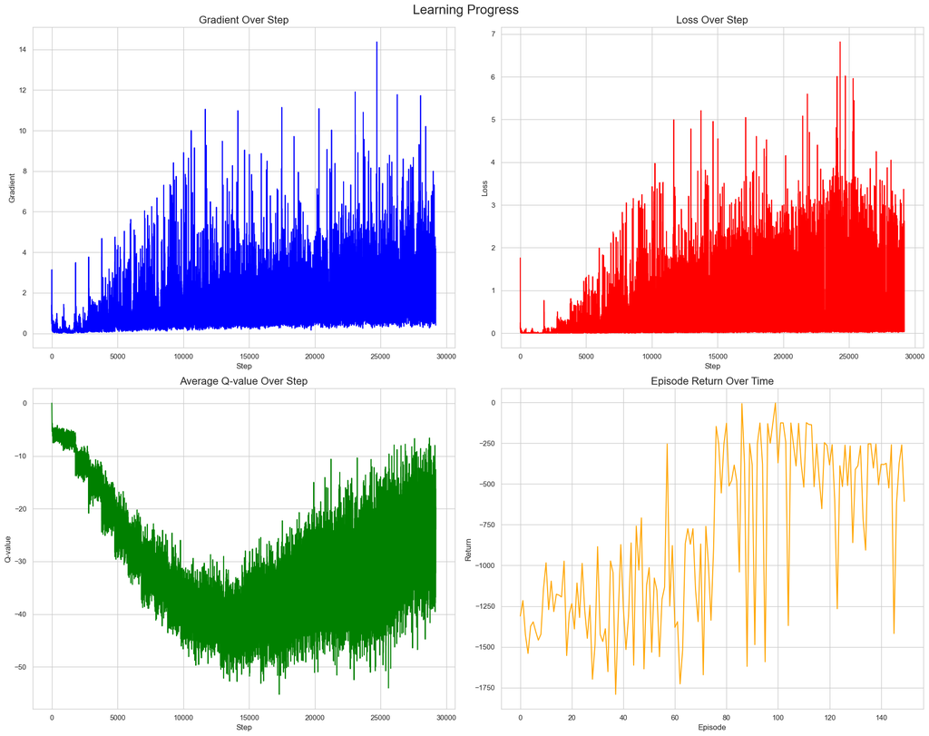

```
Final average return: -838.13
```

```python
HyperParams = namedtuple('HyperParams', [
    'intermediate_size',
    'learning_rate',
    'gamma',
    'batch_size',
    'replay_memory_size',
    'min_replay_memory',
    'update_target_every'
])

# Define the hyperparameter search space
param_dist = {
    'intermediate_size': [32, 64, 128, 256, 512],
    'learning_rate': [0.0001, 0.001, 0.01],
    'gamma': [0.9, 0.95, 0.99],
    'batch_size': [32, 64, 128],
    'replay_memory_size': [10000, 50000, 100000],
    'min_replay_memory': [1000, 5000, 10000],
    'update_target_every': [5, 10, 20]
}

def sample_hyperparams():
    sampler = ParameterSampler(param_dist, n_iter=1, random_state=random.randint(1, 1000))
    params = next(iter(sampler))
    return HyperParams(**params)

def run_experiment(params, n_episodes=150, finalFlag=False):
    baseline = DQN(
        InputShape=InputShape,
        NActions=NActions,
        IntermediateSize=params.intermediate_size,
        Gamma=params.gamma,
        ReplayMemorySize=params.replay_memory_size,
        MinReplayMemory=params.min_replay_memory,
        UpdateTargetEveryThisEpisodes=params.update_target_every,
        BatchSize=params.batch_size
    )

    baseline.Optimiser = Adam(learning_rate=params.learning_rate)

    returns = []
    for episode in range(n_episodes):
        if episode % ShowEvery == 0:
            print(f'Episode {episode}', end=' ')

        result = OneEpisode(baseline)
        if isinstance(result, dict):
            # If OneEpisode returns a dict, we'll assume it contains the return
            returns.append(result.get('return', 0))
        elif len(baseline.return_history) > 0:
            returns.append(baseline.return_history[-1])

    if finalFlag:
        create_gif(baseline)
        baseline.plot_magnitudes()
        plt.show()

    avg_return = np.mean(returns) if returns else 0
    baseline.avg_return = avg_return
    return avg_return

n_configs = 5

best_params = None
best_avg_return = float('-inf')

for i in range(n_configs):
    params = sample_hyperparams()
    print(f"\nTrying configuration {i+1}/{n_configs}:")
    print(f"Params: {params}")

    avg_return = run_experiment(params)
    print(f"Average return: {avg_return:.2f}")

    if avg_return > best_avg_return:
        best_avg_return = avg_return
        best_params = params

print("\nBest hyperparameters found:")
print(f"Params: {best_params}")
print(f"Best average return: {best_avg_return:.2f}")

# Run a final experiment with the best parameters
print("\nRunning final experiment with best parameters...")
final_avg_return = run_experiment(best_params, finalFlag=True)
print(f"Final average return: {final_avg_return:.2f}")
```

Observation

- Gradient Over Step: Shows high variability, with spikes up to 14.
- Loss Over Step: Gradually increases and stabilizes around 2-3.
- Average Q-value Over Step: Initially decreases, then increases after step 15000.
- Episode Return Over Time: Highly variable, but shows an overall upward trend.

# **Noisy DQN**

Noisy DQN is an extension of the Deep Q-Network (DQN) that incorporates stochastic noise into the neural network's parameters to encourage exploration during training. This approach aims to address the challenge of balancing exploration and exploitation in reinforcement learning.

## **Key Components of Noisy DQN**

- **Noisy Q-Network**
  - **Input Layer**: The current state of the environment.
  - **Hidden Layers**: Several layers to extract features from the state.
  - **Output Layer**: Q-values for each possible action, with added noise to encourage exploration.
- **Noisy Layers**
  - **Noise Injection**: Gaussian noise is added to the weights of the neural network to create a stochastic policy.
  - **Learnable Parameters**: The parameters of the noise distribution are learned during training, enabling adaptive exploration.
- **Experience Replay**
  - **Replay Buffer**: Stores the agent's experiences `(s, a, r, s')`.
  - **Batch Training**: Random mini-batches are sampled from the buffer for training, helping to break the correlation between consecutive experiences.
- **Target Network**
  - **Purpose**: Provides stable Q-value targets to prevent oscillations or divergence during training.
  - **Target Update**: Updated periodically with the Q-Network's weights.
- **Bellman Equation and Loss Function**
  - **Q-learning Update Rule**: $y = r + \gamma \max_{a'} Q(s', a'; \theta^-)$
  - **Loss Function**: $L(\theta) = \mathbb{E} \left[ (y - Q(s, a; \theta))^2 \right]$
- **Exploration vs. Exploitation**
  - **Adaptive Exploration**: The noise parameters are optimized along with the Q-network weights, leading to a more effective balance between exploration and exploitation over time.
  - **Reduced Dependence on ε-Greedy**: Unlike traditional DQN that relies heavily on ε-greedy exploration, Noisy DQN uses parameter noise for more consistent exploration.

## **Advantages of Noisy DQN**

- **Enhanced Exploration**: By introducing noise directly into the network parameters, the agent is encouraged to explore more diverse actions.
- **Adaptive Mechanism**: The learnable noise parameters allow the exploration strategy to adapt during training.
- **Improved Performance**: Noisy DQN often leads to better performance in environments where effective exploration is crucial.

```python
class NoisyDense(tf.keras.layers.Layer):
    def __init__(self, units, sigma=0.5, **kwargs):
        super(NoisyDense, self).__init__(**kwargs)
        self.units = units
        self.sigma = sigma

    def build(self, input_shape):
        self.w_mu = self.add_weight(name='w_mu', shape=(input_shape[-1], self.units),
                                    initializer='random_normal', trainable=True)
        self.w_sigma = self.add_weight(name='w_sigma', shape=(input_shape[-1], self.units),
                                       initializer=tf.constant_initializer(self.sigma), trainable=True)
        self.b_mu = self.add_weight(name='b_mu', shape=(self.units,),
                                    initializer='random_normal', trainable=True)
        self.b_sigma = self.add_weight(name='b_sigma', shape=(self.units,),
                                       initializer=tf.constant_initializer(self.sigma), trainable=True)

    def call(self, inputs, training=None):
        if training:
            w_noise = tf.random.normal(self.w_mu.shape)
            b_noise = tf.random.normal(self.b_mu.shape)
            return tf.matmul(inputs, self.w_mu + self.w_sigma * w_noise) + (self.b_mu + self.b_sigma * b_noise)
        return tf.matmul(inputs, self.w_mu) + self.b_mu
```

```python
class NoisyDQN:
    def __init__(self,
                 InputShape=4,
                 NActions=2,
                 Gamma=1,
                 ReplayMemorySize=10000,
                 MinReplayMemory=1000,
                 UpdateTargetEveryThisEpisodes=1,
                 IntermediateSize=64,
                 BatchSize=32):
        self.name = 'NoisyDQN'
        self.avg_return = 0

        # Hyperparameters. #
        self.InputShape = InputShape
        self.NActions = NActions
        self.Gamma = Gamma
        self.ReplayMemorySize = ReplayMemorySize
        self.MinReplayMemory = MinReplayMemory
        self.UpdateTargetEveryThisEpisodes = UpdateTargetEveryThisEpisodes
        self.IntermediateSize = IntermediateSize
        self.BatchSize = BatchSize
        self.return_history = []
        self.loss_history = []
        self.q_value_history = []
        self.gradient_history = []

        # Main model. #
        self.Main = self.CreateModel('Main')
        self.Optimiser = Adam()

        # Target model. #
        self.Target = self.CreateModel('Target')
        self.Target.set_weights(self.Main.get_weights())

        # Replay memory. #
        self.ReplayMemory = deque(maxlen=ReplayMemorySize)

        # Target network update counter. #
        self.TargetUpdateCounter = 0

    def record_episode_reward(self, episode_reward):
        self.return_history.append(episode_reward)

    def plot_magnitudes(self):
        # Create a DataFrame from our data
        df = pd.DataFrame({
            'Step': range(len(self.loss_history)),
            'Loss': self.loss_history,
            'Q-value': self.q_value_history,
            'Gradient': self.gradient_history
        })

        # Set up the plot style
        sns.set_style("whitegrid")
        sns.set_palette("deep")

        # Create the plot
        fig, axs = plt.subplots(2, 2, figsize=(20, 16))
        fig.suptitle('Learning Progress', fontsize=20)

        # Plot Gradient
        sns.lineplot(data=df, x='Step', y='Gradient', ax=axs[0, 0], color='blue')
        axs[0, 0].set_title('Gradient Over Step', fontsize=16)

        # Plot Loss
        sns.lineplot(data=df, x='Step', y='Loss', ax=axs[0, 1], color='red')
        axs[0, 1].set_title('Loss Over Step', fontsize=16)

        # Plot Q-value
        sns.lineplot(data=df, x='Step', y='Q-value', ax=axs[1, 0], color='green')
        axs[1, 0].set_title('Average Q-value Over Step', fontsize=16)

        # Plot Episode Return
        return_df = pd.DataFrame({
            'Episode': range(len(self.return_history)),
            'Return': self.return_history
        })
        sns.lineplot(data=return_df, x='Episode', y='Return', ax=axs[1, 1], color='orange')
        axs[1, 1].set_title('Episode Return Over Time', fontsize=16)

        # Adjust layout and display
        plt.tight_layout()
        plt.show()

    def CreateModel(self, Type):
        inputs = Input(shape=(self.InputShape,), name='Input')
        x = NoisyDense(self.IntermediateSize, name='1stHiddenLayer')(inputs)
        x = Activation('relu')(x)
        x = NoisyDense(self.IntermediateSize, name='2ndHiddenLayer')(x)
        x = Activation('relu')(x)
        outputs = Dense(self.NActions, activation='linear', name='Output')(x)

        NN = Model(inputs, outputs, name=f'{Type}')
        NN.summary()

        return NN

    def UpdateReplayMemory(self, Information): # Information = (S, A, R, SNext, Done)
        self.ReplayMemory.append(Information)

    def Train(self, EndOfEpisode):
        if len(self.ReplayMemory) < self.MinReplayMemory:
            return

        # Get batch of data for training. #
        TrainingData = random.sample(self.ReplayMemory, self.BatchSize)

        # Get states from training data, then get corresponding Q values. #
        ListOfS = np.array([element[0] for element in TrainingData])
        ListOfQ = np.array(self.Main(ListOfS))

        # Get future states from training data, then get corresponding Q values. #
        ListOfSNext = np.array([element[3] for element in TrainingData])
        ListOfQNext = self.Target(ListOfSNext)

        # Build actual training data for neural network. #
        X = []
        Y = []
        for index, (S, A, R, SNext, Done) in enumerate(TrainingData):
            if not Done:
                MaxQNext = np.max(ListOfQNext[index])
                QNext = R + self.Gamma * MaxQNext
            else:
                QNext = R
            Q = ListOfQ[index]
            Q[A] = QNext

            X.append(S)
            Y.append(Q)

        # Train model using tf.GradientTape(), defined below.
        Loss, Predictions, Grad = self.GTfit(X, Y)
        self.loss_history.append(float(Loss))
        self.q_value_history.append(float(tf.reduce_mean(Predictions)))
        self.gradient_history.append(float(tf.linalg.global_norm(Grad)))

        # Update target network every episode. #
        if EndOfEpisode:
            self.TargetUpdateCounter += 1

        # Update target if counter is full. #
        if self.TargetUpdateCounter >= self.UpdateTargetEveryThisEpisodes:
            self.Target.set_weights(self.Main.get_weights())
            self.TargetUpdateCounter = 0

    @tf.function
    def GTfit(self, X, Y):
        with tf.GradientTape() as tape:
            Predictions = self.Main(tf.convert_to_tensor(X), training=True)
            Loss = tf.math.reduce_mean(tf.math.square(tf.convert_to_tensor(Y) - Predictions))
        Grad = tape.gradient(Loss, self.Main.trainable_variables)
        self.Optimiser.apply_gradients(zip(Grad, self.Main.trainable_variables))
        return Loss, Predictions, Grad
```

```
Trying configuration 1/3:
Params: HyperParams(intermediate_size=128, learning_rate=0.001, gamma=0.95, batch_size=128, replay_memory_size=30000, min_replay_memory=2000, update_target_every=10, sigma=1.0)
Episode 0 Finished! Return: -1614.4344139484415
Finished! Return: -1609.2032855830353
Finished! Return: -1588.8232235971132
Finished! Return: -1604.7890099401623
Finished! Return: -1656.0964604619905
Finished! Return: -1420.2153529154177
Finished! Return: -1351.036729826551
Finished! Return: -1351.930855589213
Finished! Return: -1357.311880634588
Finished! Return: -1353.201234797398
Episode 10 Finished! Return: -1619.6316452208707
Finished! Return: -1073.2511017977333
Finished! Return: -1421.7477998720738
Finished! Return: -1310.8989144832822
Finished! Return: -1255.966176990534
Finished! Return: -1181.1870168523415
Finished! Return: -1340.838801120512
Finished! Return: -1574.6673130895222
Finished! Return: -1256.1683245574222
Finished! Return: -1453.6123082987797
Episode 20 Finished! Return: -1191.846139572759
Finished! Return: -1271.492461908686
Finished! Return: -1305.8733216761052
Finished! Return: -1371.3356435667538
Finished! Return: -948.1463059443079
Finished! Return: -1265.9434882825271
Finished! Return: -1338.5839848398323
Finished! Return: -1181.6483105625143
Finished! Return: -991.5980144821473
Finished! Return: -1619.7540695940534
Episode 30 Finished! Return: -1224.4780776863822
Finished! Return: -1319.3152371928863
Finished! Return: -1230.2065651551875
Finished! Return: -1588.8247121431996
Finished! Return: -1342.7889065091726
Finished! Return: -1218.4609438674881
Finished! Return: -1632.6015111277993
Finished! Return: -1395.723410227078
```

[output cut: 562 more lines]

```
Finished! Return: -1284.3631501197315
Finished! Return: -1487.0563937641666
Finished! Return: -1296.33394584284
Finished! Return: -1088.2214865571605
Finished! Return: -1243.400303307526
Episode 140 Finished! Return: -1343.680328717073
Finished! Return: -1173.9216246721708
Finished! Return: -1076.8535034694205
Finished! Return: -1529.8172231969806
Finished! Return: -1541.5754964964617
Finished! Return: -1396.4306456624113
Finished! Return: -1369.5514436399976
Finished! Return: -1457.0675692054238
Finished! Return: -1564.096539943123
Finished! Return: -1472.489550644554
```

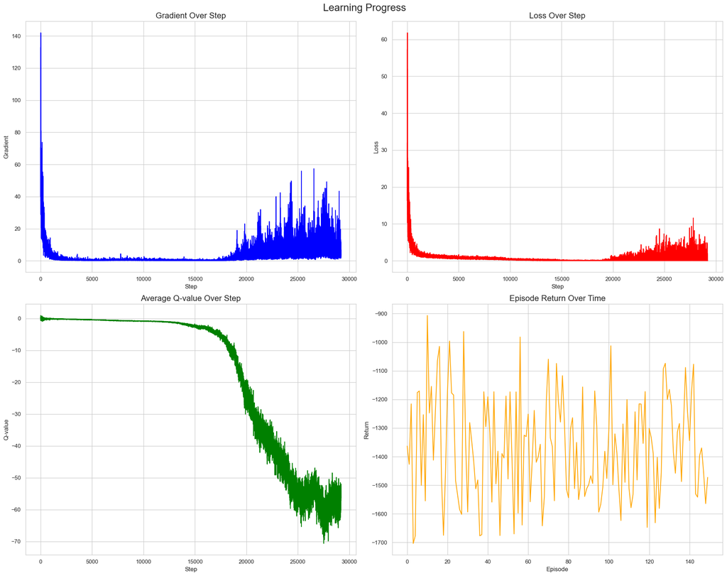

```
Final average return: -1367.53
```

```python
HyperParams = namedtuple('HyperParams', [
    'intermediate_size',
    'learning_rate',
    'gamma',
    'batch_size',
    'replay_memory_size',
    'min_replay_memory',
    'update_target_every',
    'sigma'
])

# Define the hyperparameter search space
param_dist = {
    'intermediate_size': [32, 64, 128, 256, 512],
    'learning_rate': [0.0001, 0.001, 0.01],
    'gamma': [0.9, 0.95, 0.99],
    'batch_size': [32, 64, 128],
    'replay_memory_size': [10000, 20000, 30000],
    'min_replay_memory': [1000, 2000, 4000],
    'update_target_every': [5, 10, 20],
    'sigma': [0.1, 0.3, 0.5, 0.7, 1.0]  # Added sigma values for NoisyDQN
}

def sample_hyperparams():
    sampler = ParameterSampler(param_dist, n_iter=1, random_state=random.randint(1, 1000))
    params = next(iter(sampler))
    return HyperParams(**params)

def run_experiment(params, n_episodes=150, finalFlag=False):
    # Assuming InputShape and NActions are defined elsewhere
    noisyDQN = NoisyDQN(
        InputShape=InputShape,
        NActions=NActions
    )

    noisyDQN.Optimiser = Adam(learning_rate=params.learning_rate)

    # Update sigma for NoisyDense layers
    for layer in noisyDQN.Main.layers:
        if isinstance(layer, NoisyDense):
            layer.sigma = params.sigma

    returns = []
    for episode in range(n_episodes):
        if episode % ShowEvery == 0:
            print(f'Episode {episode}', end=' ')

        result = OneEpisode(noisyDQN)
        if isinstance(result, dict):
            # If OneEpisode returns a dict, we'll assume it contains the return
            returns.append(result.get('return', 0))
        elif len(noisyDQN.return_history) > 0:
            returns.append(noisyDQN.return_history[-1])

    if finalFlag:
        create_gif(noisyDQN)
        noisyDQN.plot_magnitudes()
        plt.show()

    avg_return = np.mean(returns) if returns else 0
    noisyDQN.avg_return = avg_return
    return avg_return

n_configs = 3

best_params = None
best_avg_return = float('-inf')

for i in range(n_configs):
    params = sample_hyperparams()
    print(f"\nTrying configuration {i+1}/{n_configs}:")
    print(f"Params: {params}")

    avg_return = run_experiment(params)
    print(f"Average return: {avg_return:.2f}")

    if avg_return > best_avg_return:
        best_avg_return = avg_return
        best_params = params

print("\nBest hyperparameters found:")
print(f"Params: {best_params}")
print(f"Best average return: {best_avg_return:.2f}")

# Run a final experiment with the best parameters
print("\nRunning final experiment with best parameters...")
final_avg_return = run_experiment(best_params, n_episodes=150, finalFlag=True)
print(f"Final average return: {final_avg_return:.2f}")
```

# **Deep Deterministic Policy Gradient (`DDPG`)**

Deep Deterministic Policy Gradient (DDPG) is a model-free, off-policy reinforcement learning algorithm designed for environments with continuous action spaces. DDPG combines aspects of both Q-learning and policy gradient methods, using an actor-critic architecture. The main components include the Actor Network, Critic Network, Experience Replay, and Target Networks.

## **Key Components of DDPG**

- **Actor Network**
  - **Input Layer**: Receives the current state.
  - **Hidden Layers**: Extract features from the state.
  - **Output Layer**: Outputs a specific action for the given state.
- **Critic Network**
  - **Input Layer**: Receives the state and action.
  - **Hidden Layers**: Processes state-action pairs.
  - **Output Layer**: Outputs the Q-value representing the value of the action-state pair.
- **Experience Replay**
  - **Replay Buffer**: Stores experiences `(s, a, r, s')`.
  - **Batch Training**: Random mini-batches are used to train the networks.
- **Target Networks**
  - **Target Actor Network**: $ \mu'(s|\theta^{\mu'}) $
  - **Target Critic Network**: $ Q'(s, a|\theta^{Q'}) $
  - **Soft Updates**: $\theta' \leftarrow \tau \theta + (1 - \tau)\theta'$ where $ \tau $ is a small parameter.
- **Exploration Strategy**
  - **Noise Process**: Typically uses the Ornstein-Uhlenbeck process to add noise to actions, encouraging exploration.

```python
class DDPG:
    def __init__(self,
                 InputShape=3,
                 NActions=1,
                 Gamma=0.99,
                 ReplayMemorySize=10000,
                 MinReplayMemory=1000,
                 UpdateTargetEveryThisEpisodes=1,
                 ActorLearningRate=0.001,
                 CriticLearningRate=0.002,
                 IntermediateSize=64,
                 BatchSize=64,
                 Tau=0.005):
        self.name = 'DDPG'
        self.avg_return = 0

        # Hyperparameters
        self.InputShape = InputShape
        self.NActions = NActions
        self.Gamma = Gamma
        self.ReplayMemorySize = ReplayMemorySize
        self.MinReplayMemory = MinReplayMemory
        self.UpdateTargetEveryThisEpisodes = UpdateTargetEveryThisEpisodes
        self.ActorLearningRate = ActorLearningRate
        self.CriticLearningRate = CriticLearningRate
        self.IntermediateSize = IntermediateSize
        self.BatchSize = BatchSize
        self.Tau = Tau

        # History
        self.return_history = []
        self.loss_history = []
        self.q_value_history = []
        self.gradient_history = []
        self.sd_history = []

        # Actor and Critic models
        self.Actor = self.create_actor('Actor')
        self.Critic = self.create_critic('Critic')

        # Target models
        self.TargetActor = self.create_actor('TargetActor')
        self.TargetActor.set_weights(self.Actor.get_weights())
        self.TargetCritic = self.create_critic('TargetCritic')
        self.TargetCritic.set_weights(self.Critic.get_weights())

        # Optimizers
        self.ActorOptimizer = Adam(learning_rate=self.ActorLearningRate)
        self.CriticOptimizer = Adam(learning_rate=self.CriticLearningRate)

        # Replay memory
        self.ReplayMemory = deque(maxlen=self.ReplayMemorySize)

        # Target network update counter
        self.TargetUpdateCounter = 0

    def record_episode_reward(self, episode_reward):
        self.return_history.append(episode_reward)

    def create_actor(self, name):
        inputs = Input(shape=(self.InputShape,))
        x = Dense(self.IntermediateSize, activation='relu')(inputs)
        x = Dense(self.IntermediateSize, activation='relu')(x)
        outputs = Dense(self.NActions, activation='tanh')(x)
        model = Model(inputs, outputs, name=name)
        return model

    def create_critic(self, name):
        state_input = Input(shape=(self.InputShape,))
        action_input = Input(shape=(self.NActions,))
        concat = tf.concat([state_input, action_input], axis=-1)
        x = Dense(self.IntermediateSize, activation='relu')(concat)
        x = Dense(self.IntermediateSize, activation='relu')(x)
        outputs = Dense(1)(x)
        model = Model([state_input, action_input], outputs, name=name)
        return model

    def update_replay_memory(self, information):  # Information = (S, A, R, SNext, Done)
        self.ReplayMemory.append(information)

    def train(self, end_of_episode):
        if len(self.ReplayMemory) < self.MinReplayMemory:
            return

        # Get batch of data for training
        training_data = random.sample(self.ReplayMemory, self.BatchSize)

        # Get states, actions, rewards, next states, and done flags from training data
        states = np.array([data[0] for data in training_data])
        actions = np.array([data[1] for data in training_data])
        rewards = np.array([data[2] for data in training_data])
        next_states = np.array([data[3] for data in training_data])
        dones = np.array([data[4] for data in training_data])

        # Update critic
        next_actions = self.TargetActor(next_states)
        q_next = self.TargetCritic([next_states, next_actions])
        q_targets = rewards + self.Gamma * q_next * (1 - dones)
        with tf.GradientTape() as tape:
            q_values = self.Critic([states, actions])
            critic_loss = tf.reduce_mean(tf.square(q_targets - q_values))
        critic_grads = tape.gradient(critic_loss, self.Critic.trainable_variables)
        self.CriticOptimizer.apply_gradients(zip(critic_grads, self.Critic.trainable_variables))

        # Update actor
        with tf.GradientTape() as tape:
            actions_pred = self.Actor(states)
            actor_loss = -tf.reduce_mean(self.Critic([states, actions_pred]))
        actor_grads = tape.gradient(actor_loss, self.Actor.trainable_variables)
        self.ActorOptimizer.apply_gradients(zip(actor_grads, self.Actor.trainable_variables))

        # Soft update target networks
        self.update_target_network(self.TargetActor, self.Actor)
        self.update_target_network(self.TargetCritic, self.Critic)

        # Record history
        self.loss_history.append(float(critic_loss))
        self.q_value_history.append(float(tf.reduce_mean(q_values)))
        self.gradient_history.append(float(tf.linalg.global_norm(critic_grads)))

        if end_of_episode:
            self.TargetUpdateCounter += 1

    def update_target_network(self, target, source):
        target_weights = target.get_weights()
        source_weights = source.get_weights()
        new_weights = [(1 - self.Tau) * target_weight + self.Tau * source_weight for target_weight, source_weight in zip(target_weights, source_weights)]
        target.set_weights(new_weights)

    def plot_magnitudes(self):
        # Create a DataFrame from our data
        df = pd.DataFrame({
            'Step': range(len(self.loss_history)),
            'Loss': self.loss_history,
            'Q-value': self.q_value_history,
            'Gradient': self.gradient_history
        })

        # Set up the plot style
        sns.set_style("whitegrid")
        sns.set_palette("deep")

        # Create the plot
        fig, axs = plt.subplots(2, 2, figsize=(20, 16))
        fig.suptitle('Learning Progress', fontsize=20)

        # Plot Loss, Q-value, and Gradient
        sns.lineplot(data=df, x='Step', y='Gradient', ax=axs[0, 0], color='blue')
        axs[0, 0].set_title('Gradient Over Step', fontsize=16)

        # Plot Loss separately
        sns.lineplot(data=df, x='Step', y='Loss', ax=axs[0, 1], color='red')
        axs[0, 1].set_title('Loss Over Step', fontsize=16)

        # Plot Q-value separately
        sns.lineplot(data=df, x='Step', y='Q-value', ax=axs[1, 0], color='green')
        axs[1, 0].set_title('Average Q-value Over Step', fontsize=16)

        # Plot Episode Reward
        return_df = pd.DataFrame({
            'Episode': range(len(self.return_history)),
            'Return': self.return_history
        })
        sns.lineplot(data=return_df, x='Episode', y='Return', ax=axs[1, 1], color='orange')
        axs[1, 1].set_title('Episode Return Over Time', fontsize=16)

        # Adjust layout and display
        plt.tight_layout()
        plt.show()
```

```python
def pendulum_action_converter(a, n_actions):
    return (a / n_actions - 0.5) * 4

def pendulum_inverse_action_converter(a, n_actions):
    return round((a + 2) * (n_actions - 1) / 4)

def one_episode(agent, env, epsilon=0.1):
    state = env.reset()
    state = state.reshape(1, -1)  # Reshape state to (1, state_dim)
    list_of_rewards = []
    done = False
    truncated = False
    while not (done or truncated):
        if np.random.rand() < epsilon:
            action = env.action_space.sample()
        else:
            action = agent.Actor(state).numpy()[0]

        # Adapt to the environment's step function
        try:
            next_state, reward, done, truncated, _ = env.step(action)
        except ValueError:
            next_state, reward, done, _ = env.step(action)
            truncated = False  # Handle missing truncated flag

        next_state = next_state.reshape(1, -1)  # Reshape next_state to (1, state_dim)

        agent.update_replay_memory((state[0], action, reward, next_state[0], done))
        agent.train(done or truncated)
        list_of_rewards.append(reward)

        Total_Reward = np.sum(list_of_rewards)
        SD_Reward = np.std(list_of_rewards)

        if done or truncated:
            agent.sd_history.append(SD_Reward)
            agent.return_history.append(Total_Reward)
            print(f'Finished! Return: {Total_Reward}')
            return Total_Reward

        state = next_state


def create_ddpg_gif(agent, epsilon=0.1):
    env = gym.make(f'{EnvName}')
    state = env.reset()
    state = state.reshape(1, -1)  # Reshape state to (1, state_dim)
    done = False
    truncated = False
    frames = []

    while not (done or truncated):
        if np.random.rand() < epsilon:
            action = env.action_space.sample()
        else:
            action = agent.Actor(state).numpy()[0]

        # Adapt to the environment's step function
        try:
            next_state, reward, done, truncated, _ = env.step(action)
        except ValueError:
            next_state, reward, done, _ = env.step(action)
            truncated = False  # Handle missing truncated flag

        frame = env.render(mode='rgb_array')
        frames.append(frame)
        next_state = next_state.reshape(1, -1)  # Reshape next_state to (1, state_dim)

        agent.update_replay_memory((state[0], action, reward, next_state[0], done))
        agent.train(done or truncated)
        state = next_state

    imageio.mimsave(f'./CA2-Output/RL-Training/{agent.name}_.gif', frames, fps=30)
    env.close()
    # Save frames as gif
```

```
Trying configuration 1/3:
Gamma: 0.999, ReplayMemorySize: 25000, MinReplayMemory: 2000, UpdateTargetEveryThisEpisodes: 5, ActorLearningRate: 0.001, CriticLearningRate: 0.0002, IntermediateSize: 64, BatchSize: 128, Tau: 0.001
Episode 0 Finished! Return: -593.400020668769
Finished! Return: -696.4851871779022
Finished! Return: -923.3567764169292
Episode 3 Finished! Return: -721.712157120337
Finished! Return: -919.6282189971648
Finished! Return: -533.3028044242717
Episode 6 Finished! Return: -380.9875313280093
Finished! Return: -583.8998363821541
Finished! Return: -624.345102086218
Episode 9 Finished! Return: -839.8687183960673
Finished! Return: -903.4637722218778
Finished! Return: -894.537126871932
Episode 12 Finished! Return: -849.9162000869495
Finished! Return: -527.7336495347621
Finished! Return: -533.5908305285886
Episode 15 Finished! Return: -666.6921887274268
Finished! Return: -513.1474909658705
Finished! Return: -676.1428779747886
Episode 18 Finished! Return: -652.2492145122316
Finished! Return: -889.9638785931323
Finished! Return: -747.5884909745159
Episode 21 Finished! Return: -665.5830642168866
Finished! Return: -906.8258976757121
Finished! Return: -537.0085464137496
Episode 24 Finished! Return: -578.1768660396302
Finished! Return: -667.0382886915901
Finished! Return: -636.5625786739042
Episode 27 Finished! Return: -672.6385330746351
Finished! Return: -663.2270015929506
Finished! Return: -900.2021913707234
Episode 30 Finished! Return: -578.7945093564762
Finished! Return: -521.3990877957923
Finished! Return: -543.0020556753908
Episode 33 Finished! Return: -497.7612252479621
Finished! Return: -471.88801144566327
Finished! Return: -478.9797908410509
Episode 36 Finished! Return: -541.3836688322986
Finished! Return: -915.1249068492464
```

[output cut: 570 more lines]

```
Episode 135 Finished! Return: -537.9223043606847
Finished! Return: -875.718659680111
Finished! Return: -845.7635548115139
Episode 138 Finished! Return: -858.7109216401141
Finished! Return: -489.34005783032944
Finished! Return: -552.5287074821459
Episode 141 Finished! Return: -874.9984759246228
Finished! Return: -872.7465750861195
Finished! Return: -874.4975940441773
Episode 144 Finished! Return: -791.3928745185584
Finished! Return: -865.0367389148266
Finished! Return: -695.0062472438558
Episode 147 Finished! Return: -619.4377395406399
Finished! Return: -588.8081572323221
Finished! Return: -486.82436221257603
```

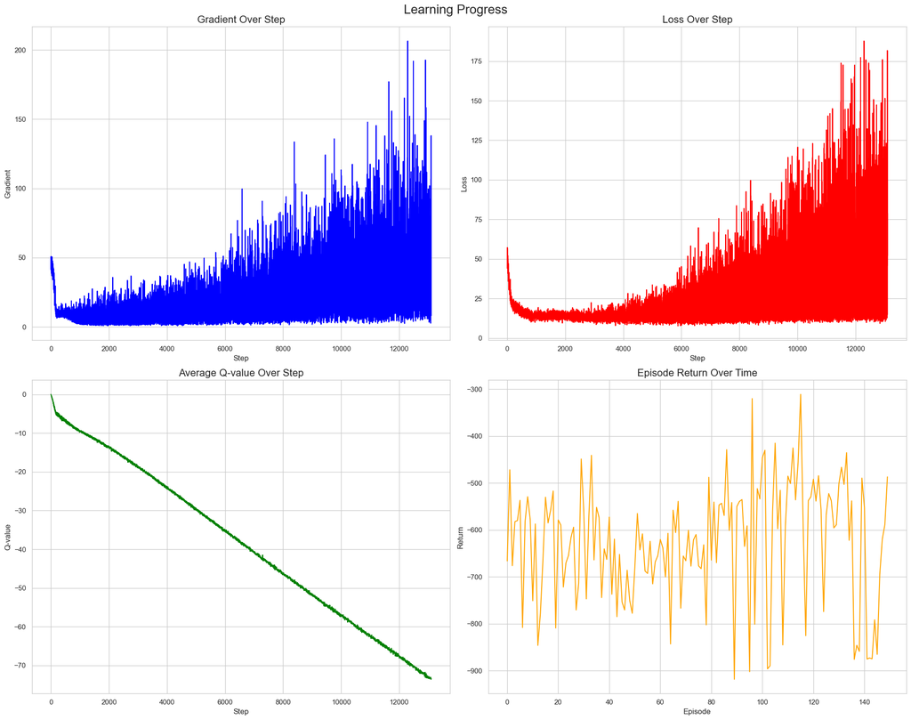

```
Final average return: -627.46
```

```python
HyperParams = namedtuple('HyperParams', [
    'input_shape', 'n_actions', 'gamma', 'replay_memory_size', 'min_replay_memory',
    'update_target_every_this_episodes', 'actor_learning_rate', 'critic_learning_rate',
    'intermediate_size', 'batch_size', 'tau'
])

def random_hyperparams():
    return HyperParams(
        input_shape=None,
        n_actions=None,
        gamma=random.choice([0.95, 0.99, 0.999]),
        replay_memory_size=random.choice([10000, 20000, 25000]),
        min_replay_memory=random.choice([1000, 2000, 2500]),
        update_target_every_this_episodes=random.choice([1, 2, 5]),
        actor_learning_rate=random.choice([0.0001, 0.001, 0.01]),
        critic_learning_rate=random.choice([0.0002, 0.002, 0.02]),
        intermediate_size=random.choice([32, 64, 128, 256]),
        batch_size=random.choice([32, 64, 128]),
        tau=random.choice([0.001, 0.005, 0.01])
    )

def run_experiment(params, n_episodes=150, finalFlag=False):
    env = gym.make("Pendulum-v0")
    params = params._replace(input_shape=env.observation_space.shape[0], n_actions=env.action_space.shape[0])

    ddpg = DDPG(InputShape=params.input_shape,
                NActions=params.n_actions,
                Gamma=params.gamma,
                ReplayMemorySize=params.replay_memory_size,
                MinReplayMemory=params.min_replay_memory,
                UpdateTargetEveryThisEpisodes=params.update_target_every_this_episodes,
                ActorLearningRate=params.actor_learning_rate,
                CriticLearningRate=params.critic_learning_rate,
                IntermediateSize=params.intermediate_size,
                BatchSize=params.batch_size,
                Tau=params.tau)

    returns = []
    ShowEvery = 3
    for episode in range(n_episodes):
        if episode % ShowEvery == 0:
            print(f'Episode {episode}', end=' ')
        one_episode(ddpg, env)
        if len(ddpg.return_history) > 0:
            returns.append(ddpg.return_history[-1])
    if finalFlag:
        create_ddpg_gif(ddpg)
        ddpg.plot_magnitudes()
        plt.show()
    avg_return = sum(returns) / len(returns) if returns else 0
    ddpg.avg_return = avg_return
    return avg_return

n_configs = 3  # Number of random iterations

best_params = None
best_avg_return = float('-inf')

for i in range(n_configs):
    params = random_hyperparams()
    print(f"\nTrying configuration {i+1}/{n_configs}:")
    print(f"Gamma: {params.gamma}, "
          f"ReplayMemorySize: {params.replay_memory_size}, "
          f"MinReplayMemory: {params.min_replay_memory}, "
          f"UpdateTargetEveryThisEpisodes: {params.update_target_every_this_episodes}, "
          f"ActorLearningRate: {params.actor_learning_rate}, "
          f"CriticLearningRate: {params.critic_learning_rate}, "
          f"IntermediateSize: {params.intermediate_size}, "
          f"BatchSize: {params.batch_size}, "
          f"Tau: {params.tau}")

    avg_return = run_experiment(params)
    print(f"Average return: {avg_return:.2f}")

    if avg_return > best_avg_return:
        best_avg_return = avg_return
        best_params = params

print("\nBest hyperparameters found:")
for field in best_params._fields:
    if field not in ['input_shape', 'n_actions']:
        print(f"{field}: {getattr(best_params, field)}")
print(f"Best average return: {best_avg_return:.2f}")

# Run a final experiment with the best parameters
print("\nRunning final experiment with best parameters...")
final_avg_return = run_experiment(best_params, finalFlag=True)
print(f"Final average return: {final_avg_return:.2f}")
```

Observation

- Gradient Over Step: Gradually increases with high variability.
- Loss Over Step: Initially drops, then steadily increases.
- Average Q-value Over Step: Consistently decreases linearly.
- Episode Return Over Time: Fluctuates but shows a slight upward trend.

# **Model Evaluation**

```python
compared_agents = {
    "Model": [baseline.name, noisyDQN.name, ddpg.name],
    "Average Return": [baseline.avg_return, noisyDQN.avg_return, ddpg.avg_return]
}
```

```python
compared_agents = pd.DataFrame(compared_agents)

def highlight_max(dataframe):
    max_return_index = dataframe["Average Return"].idxmax()
    return pd.DataFrame([['background-color: yellow' if i == max_return_index else '' for i in range(len(dataframe))]], index=[''])

styled_df = compared_agents.style.apply(highlight_max, axis=0)

styled_df = compared_agents.style.apply(lambda x: ['background-color: Green' if x.name == compared_agents["Average Return"].idxmax() else '' for _ in x], axis=1)

styled_df
```

|  | Model | Average Return |
| --- | --- | --- |
| 0 | Baseline | -838.130000 |
| 1 | NoisyDQN | -1367.530000 |
| 2 | DDPG | -627.460000 |

Although DDPG isn't very stable, with the right hypertuning & modifications to it, it can be more stable.

# **Model Improvement**

### **Hyper Parameter**

- `Learning Rates (ActorLearningRate & CriticLearningRate)` - These are crucial because they determine how quickly the actor and critic networks learn. The actor updates the policy based on the gradient of expected return, and the critic updates the value function estimates. Inappropriate rates can lead to diverging or very slow learning.
- `Gamma (Discount Factor)` - This parameter influences how much the agent values immediate rewards versus future rewards. A higher gamma makes the agent prioritize future rewards more heavily, potentially improving long-term strategies.
- `Intermediate Size` - Typically refers to the dimensions of hidden layers in the neural networks. This can affect the model's capacity to learn complex policies but is often less sensitive than other parameters.
- `Batch Size` - Influences the stability of learning by determining how many experiences are used to update the network at once. Larger batch sizes can provide more stable, but possibly slower, updates.

#### **Tune Learning Rate**

```python
# Learning rate hyperparameter search
learning_rates = [0.001, 0.01, 0.1]
best_lr = None
best_avg_return = -np.inf
n_episodes = 100
DF_learningRate = {
    'Learning Rate': [],
    'Average Return': []
}

for lr in learning_rates:
    print(f"Testing learning rate: {lr}")
    env = gym.make("Pendulum-v0")
    agent = DDPG()
    agent.ActorOptimizer = Adam(learning_rate=lr)
    agent.CriticOptimizer = Adam(learning_rate=lr)
    returns = []
    for episode in range(n_episodes):
        if episode % ShowEvery == 0:
            print(f'Episode {episode}', end=' ')
        result = one_episode(agent, env)
        returns.append(result)
    DF_learningRate['Average Return'].append(np.mean(returns))
    DF_learningRate['Learning Rate'].append(lr)
    avg_return = np.mean(returns) if returns else 0
    print(f"Average return: {avg_return}")
    best_lr = max(DF_learningRate["Learning Rate"])
    best_avg_return = max(DF_learningRate["Average Return"])

print(f"Best learning rate: {best_lr} with average return: {best_avg_return}")
```

```
Testing learning rate: 0.001
Episode 0 Finished! Return: -610.1513599142262
Episode 1 Finished! Return: -593.1030311264524
Episode 2 Finished! Return: -818.7449800698467
Episode 3 Finished! Return: -655.9199227495587
Episode 4 Finished! Return: -666.4729757910462
Episode 5 Finished! Return: -642.5116803900399
Episode 6 Finished! Return: -602.922728663648
Episode 7 Finished! Return: -611.8055583927464
Episode 8 Finished! Return: -660.7766891461788
Episode 9 Finished! Return: -823.6853505696549
Episode 10 Finished! Return: -862.518645166949
Episode 11 Finished! Return: -484.11349405064664
Episode 12 Finished! Return: -661.1744592593309
Episode 13 Finished! Return: -739.1800152154519
Episode 14 Finished! Return: -683.3187430980046
Episode 15 Finished! Return: -517.6834158971922
Episode 16 Finished! Return: -566.9700178595309
Episode 17 Finished! Return: -699.4589542544767
Episode 18 Finished! Return: -674.8081652167643
Episode 19 Finished! Return: -426.07790637531303
Episode 20 Finished! Return: -637.3434236058725
Episode 21 Finished! Return: -533.3910346550773
Episode 22 Finished! Return: -530.3304829516254
Episode 23 Finished! Return: -806.9120931456512
Episode 24 Finished! Return: -668.4761293802301
Episode 25 Finished! Return: -663.6998513267835
Episode 26 Finished! Return: -683.05997008741
Episode 27 Finished! Return: -373.7917294047816
Episode 28 Finished! Return: -769.3904887490297
Episode 29 Finished! Return: -653.0402634535138
Episode 30 Finished! Return: -507.6670516147439
Episode 31 Finished! Return: -496.3361720842737
Episode 32 Finished! Return: -644.7645764857316
Episode 33 Finished! Return: -596.8150655979555
Episode 34 Finished! Return: -553.6667087723921
Episode 35 Finished! Return: -564.9938781775669
Episode 36 Finished! Return: -627.821701230321
Episode 37 Finished! Return: -599.1276932182175
Episode 38 Finished! Return: -581.6579601263309
```

[output cut: 252 more lines]

```
Episode 87 Finished! Return: -652.6912234372609
Episode 88 Finished! Return: -799.6374518889857
Episode 89 Finished! Return: -865.0870206617647
Episode 90 Finished! Return: -660.648479929057
Episode 91 Finished! Return: -779.3438198083697
Episode 92 Finished! Return: -681.4825945927944
Episode 93 Finished! Return: -805.4269245965972
Episode 94 Finished! Return: -869.4110224387969
Episode 95 Finished! Return: -763.1110166564745
Episode 96 Finished! Return: -776.8247829131564
Episode 97 Finished! Return: -592.8773764483899
Episode 98 Finished! Return: -628.6390250487303
Episode 99 Finished! Return: -656.7129353639573
Average return: -676.7451186689515
Best learning rate: 0.1 with average return: -625.660182853024
```

#### **Tune Gamma**

```python
# Gamma hyperparameter search
gammas = [0.9, 0.95, 0.99]
best_gamma = None
best_avg_return = -np.inf
n_episodes = 100
ShowEvery = 1  # Adjust this as needed

DF_Gamma = {
    'Gamma': [],
    'Average Return': []
}

for gamma in gammas:
    print(f"Testing Gamma: {gamma}")
    agent = DDPG(Gamma=gamma)
    agent.ActorOptimizer = Adam(learning_rate=best_lr)
    agent.CriticOptimizer = Adam(learning_rate=best_lr)
    returns = []
    for episode in range(n_episodes):
        if episode % ShowEvery == 0:
            print(f'Episode {episode}', end=' ')
        result = one_episode(agent, env)
        returns.append(result)
    avg_return = np.mean(returns) if returns else 0
    DF_Gamma['Average Return'].append(avg_return)
    DF_Gamma['Gamma'].append(gamma)
    print(f"Average return: {avg_return}")
    if avg_return > best_avg_return:
        best_avg_return = avg_return
        best_gamma = gamma

print(f"Best Gamma: {best_gamma} with average return: {best_avg_return}")
```

```
Testing Gamma: 0.9
Episode 0 Finished! Return: -476.89823613605876
Episode 1 Finished! Return: -593.0358774803392
Episode 2 Finished! Return: -723.4183053639435
Episode 3 Finished! Return: -537.33860937478
Episode 4 Finished! Return: -519.9600061979663
Episode 5 Finished! Return: -528.6576599083961
Episode 6 Finished! Return: -567.9663673998157
Episode 7 Finished! Return: -507.09821903374274
Episode 8 Finished! Return: -594.9264667453573
Episode 9 Finished! Return: -572.0624513423079
Episode 10 Finished! Return: -582.6793643360211
Episode 11 Finished! Return: -586.3805809483782
Episode 12 Finished! Return: -813.7172358534044
Episode 13 Finished! Return: -493.47090326979924
Episode 14 Finished! Return: -716.6651744910664
Episode 15 Finished! Return: -636.814758830162
Episode 16 Finished! Return: -595.995388043133
Episode 17 Finished! Return: -812.2569354564846
Episode 18 Finished! Return: -431.8116445407743
Episode 19 Finished! Return: -876.8597218502491
Episode 20 Finished! Return: -579.3699877553074
Episode 21 Finished! Return: -905.5628090520752
Episode 22 Finished! Return: -473.87769304998585
Episode 23 Finished! Return: -613.3089957568951
Episode 24 Finished! Return: -431.2680513539926
Episode 25 Finished! Return: -535.097527888549
Episode 26 Finished! Return: -483.9597511178935
Episode 27 Finished! Return: -662.034049885378
Episode 28 Finished! Return: -478.5416229417735
Episode 29 Finished! Return: -494.3237500637009
Episode 30 Finished! Return: -461.9016404124623
Episode 31 Finished! Return: -794.3650463429075
Episode 32 Finished! Return: -803.1919231413561
Episode 33 Finished! Return: -630.1175458973106
Episode 34 Finished! Return: -380.5039090666474
Episode 35 Finished! Return: -447.153919180591
Episode 36 Finished! Return: -511.7124051063082
Episode 37 Finished! Return: -915.8475065649026
Episode 38 Finished! Return: -484.23099272235714
```

[output cut: 252 more lines]

```
Episode 87 Finished! Return: -519.8906242102294
Episode 88 Finished! Return: -556.713335092409
Episode 89 Finished! Return: -553.2771302488718
Episode 90 Finished! Return: -717.1057935730889
Episode 91 Finished! Return: -461.1759008318618
Episode 92 Finished! Return: -626.8074911584815
Episode 93 Finished! Return: -577.3646380897355
Episode 94 Finished! Return: -457.61849659943726
Episode 95 Finished! Return: -612.3781718100632
Episode 96 Finished! Return: -552.0101128961124
Episode 97 Finished! Return: -690.3096335832679
Episode 98 Finished! Return: -835.6227432336573
Episode 99 Finished! Return: -505.85181192489006
Average return: -665.686797867525
Best Gamma: 0.9 with average return: -588.5979002622657
```

#### **Tune Batch Size**

```python
# Batch Size hyperparameter search
batch_sizes = [16, 32, 64]
best_batch_size = None
best_avg_return = -np.inf
n_episodes = 100
ShowEvery = 1  # Adjust this as needed

DF_BatchSize = {
    'Batch Size': [],
    'Average Return': []
}

for batch_size in batch_sizes:
    print(f"Testing Batch Size: {batch_size}")
    agent = DDPG(BatchSize=batch_size)
    agent.ActorOptimizer = Adam(learning_rate=best_lr)
    agent.CriticOptimizer = Adam(learning_rate=best_lr)
    agent.Gamma = best_gamma
    returns = []
    for episode in range(n_episodes):
        if episode % ShowEvery == 0:
            print(f'Episode {episode}', end=' ')
        result = one_episode(agent, env)
        returns.append(result)
    avg_return = np.mean(returns) if returns else 0
    DF_BatchSize['Average Return'].append(avg_return)
    DF_BatchSize['Batch Size'].append(batch_size)
    print(f"Average return: {avg_return}")
    if avg_return > best_avg_return:
        best_avg_return = avg_return
        best_batch_size = batch_size

print(f"Best Batch Size: {best_batch_size} with average return: {best_avg_return}")
```

```
Testing Batch Size: 16
Episode 0 Finished! Return: -808.1741715971281
Episode 1 Finished! Return: -710.960450759326
Episode 2 Finished! Return: -803.4333425755691
Episode 3 Finished! Return: -893.6077054138666
Episode 4 Finished! Return: -578.6734292164892
Episode 5 Finished! Return: -549.3778867439604
Episode 6 Finished! Return: -577.7292308037012
Episode 7 Finished! Return: -799.0602131421521
Episode 8 Finished! Return: -602.1988943762783
Episode 9 Finished! Return: -515.0837908886095
Episode 10 Finished! Return: -541.4811885887452
Episode 11 Finished! Return: -851.222004824888
Episode 12 Finished! Return: -536.244916529638
Episode 13 Finished! Return: -720.4500359031002
Episode 14 Finished! Return: -505.73982811037615
Episode 15 Finished! Return: -887.61939158054
Episode 16 Finished! Return: -566.7574242868748
Episode 17 Finished! Return: -554.1253799788245
Episode 18 Finished! Return: -620.7859833874344
Episode 19 Finished! Return: -684.3825621604242
Episode 20 Finished! Return: -664.1412334898998
Episode 21 Finished! Return: -755.1016546604842
Episode 22 Finished! Return: -713.968758785167
Episode 23 Finished! Return: -521.5648586474533
Episode 24 Finished! Return: -535.0656532513278
Episode 25 Finished! Return: -594.4968991727991
Episode 26 Finished! Return: -518.3076482990022
Episode 27 Finished! Return: -644.5568530568221
Episode 28 Finished! Return: -430.1523627219943
Episode 29 Finished! Return: -657.712328755337
Episode 30 Finished! Return: -553.7932754855321
Episode 31 Finished! Return: -571.9371034529969
Episode 32 Finished! Return: -428.19279690499707
Episode 33 Finished! Return: -485.06509141579573
Episode 34 Finished! Return: -531.9563225174352
Episode 35 Finished! Return: -835.0986648725295
Episode 36 Finished! Return: -520.6776896531034
Episode 37 Finished! Return: -426.8296265241644
Episode 38 Finished! Return: -688.8774338215794
```

[output cut: 252 more lines]

```
Episode 87 Finished! Return: -667.2220950181808
Episode 88 Finished! Return: -684.9264993772254
Episode 89 Finished! Return: -599.1745092377163
Episode 90 Finished! Return: -839.0753402647289
Episode 91 Finished! Return: -832.1455179465188
Episode 92 Finished! Return: -457.2873848148834
Episode 93 Finished! Return: -602.4283544058578
Episode 94 Finished! Return: -587.9643688128941
Episode 95 Finished! Return: -448.67491482105754
Episode 96 Finished! Return: -604.5681012044035
Episode 97 Finished! Return: -476.19593320149414
Episode 98 Finished! Return: -777.9459645748582
Episode 99 Finished! Return: -451.15510883243627
Average return: -616.3762624264082
Best Batch Size: 16 with average return: -586.7609006239342
```

#### **Tune Intermediate Size**

```python
# Intermediate Size hyperparameter search
intermediate_sizes = [32, 64, 128]
best_intermediate_size = None
best_avg_return = -np.inf
n_episodes = 100
ShowEvery = 1  # Adjust this as needed

DF_IntermediateSize = {
    'Intermediate Size': [],
    'Average Return': []
}

for intermediate_size in intermediate_sizes:
    print(f"Testing Intermediate Size: {intermediate_size}")
    agent = DDPG(IntermediateSize=intermediate_size)
    agent.ActorOptimizer = Adam(learning_rate=best_lr)
    agent.CriticOptimizer = Adam(learning_rate=best_lr)
    agent.Gamma = best_gamma
    agent.BatchSize = best_batch_size
    returns = []
    for episode in range(n_episodes):
        if episode % ShowEvery == 0:
            print(f'Episode {episode}', end=' ')
        result = one_episode(agent, env)
        returns.append(result)
    avg_return = np.mean(returns) if returns else 0
    DF_IntermediateSize['Average Return'].append(avg_return)
    DF_IntermediateSize['Intermediate Size'].append(intermediate_size)
    print(f"Average return: {avg_return}")
    if avg_return > best_avg_return:
        best_avg_return = avg_return
        best_intermediate_size = intermediate_size

print(f"Best Intermediate Size: {best_intermediate_size} with average return: {best_avg_return}")
```

```
Testing Intermediate Size: 32
Episode 0 Finished! Return: -564.4822895428597
Episode 1 Finished! Return: -580.3284345865668
Episode 2 Finished! Return: -841.2339995570441
Episode 3 Finished! Return: -573.1527264333961
Episode 4 Finished! Return: -558.8293813274745
Episode 5 Finished! Return: -905.8383588664433
Episode 6 Finished! Return: -545.3081006085931
Episode 7 Finished! Return: -796.6811342897782
Episode 8 Finished! Return: -606.7288424857977
Episode 9 Finished! Return: -613.7439881608631
Episode 10 Finished! Return: -678.9456299520194
Episode 11 Finished! Return: -596.1938964719868
Episode 12 Finished! Return: -544.2358855597486
Episode 13 Finished! Return: -653.083153221896
Episode 14 Finished! Return: -598.0930642935773
Episode 15 Finished! Return: -591.8386781873544
Episode 16 Finished! Return: -655.31646305754
Episode 17 Finished! Return: -618.2629340779371
Episode 18 Finished! Return: -584.5191497815068
Episode 19 Finished! Return: -718.3061485498803
Episode 20 Finished! Return: -761.326212254194
Episode 21 Finished! Return: -856.0796516980399
Episode 22 Finished! Return: -740.0613261141082
Episode 23 Finished! Return: -839.4349333935046
Episode 24 Finished! Return: -840.026537668119
Episode 25 Finished! Return: -545.8564273093476
Episode 26 Finished! Return: -488.3000025688498
Episode 27 Finished! Return: -613.8914516599272
Episode 28 Finished! Return: -800.5346529250031
Episode 29 Finished! Return: -680.6909064289621
Episode 30 Finished! Return: -825.2687136366512
Episode 31 Finished! Return: -676.0815992501105
Episode 32 Finished! Return: -654.7081956608561
Episode 33 Finished! Return: -666.2808716072518
Episode 34 Finished! Return: -683.7655823501999
Episode 35 Finished! Return: -588.1336578051798
Episode 36 Finished! Return: -860.4225005374398
Episode 37 Finished! Return: -675.9165433570474
Episode 38 Finished! Return: -789.1420831373179
```

[output cut: 252 more lines]

```
Episode 87 Finished! Return: -635.1475053467556
Episode 88 Finished! Return: -643.942992737563
Episode 89 Finished! Return: -662.480607121104
Episode 90 Finished! Return: -579.6479713915431
Episode 91 Finished! Return: -833.2524489226103
Episode 92 Finished! Return: -668.4047445723113
Episode 93 Finished! Return: -579.6213543694155
Episode 94 Finished! Return: -594.7246844453482
Episode 95 Finished! Return: -823.7152513649952
Episode 96 Finished! Return: -585.2735196076801
Episode 97 Finished! Return: -863.5155724669522
Episode 98 Finished! Return: -543.7300273134748
Episode 99 Finished! Return: -835.3746172213931
Average return: -676.3751551158083
Best Intermediate Size: 32 with average return: -668.5987805861946
```

#### **Best Results**

```python
import pandas as pd

# DataFrames for each parameter
df_lr = pd.DataFrame(DF_learningRate)
df_gamma = pd.DataFrame(DF_Gamma)
df_batch = pd.DataFrame(DF_BatchSize)
df_intermediate = pd.DataFrame(DF_IntermediateSize)

# Add 'Parameter Type' column to each dataframe
df_lr['Parameter Type'] = 'Learning Rate'
df_gamma['Parameter Type'] = 'Gamma'
df_batch['Parameter Type'] = 'Batch Size'
df_intermediate['Parameter Type'] = 'Intermediate Size'

# Rename columns for consistency
df_lr = df_lr.rename(columns={'Learning Rate': 'Parameter Value'})
df_gamma = df_gamma.rename(columns={'Gamma': 'Parameter Value'})
df_batch = df_batch.rename(columns={'Batch Size': 'Parameter Value'})
df_intermediate = df_intermediate.rename(columns={'Intermediate Size': 'Parameter Value'})

# Concatenate all dataframes
combined_df = pd.concat([df_lr, df_gamma, df_batch, df_intermediate], ignore_index=True)

# Set 'Parameter Type' as index
final_df = combined_df.set_index('Parameter Type')

final_df
```

| Parameter Type | Parameter Value | Average Return |
| --- | --- | --- |
| Learning Rate | 0.001 | -625.660183 |
| Learning Rate | 0.010 | -728.164443 |
| Learning Rate | 0.100 | -676.745119 |
| Gamma | 0.900 | -588.597900 |
| Gamma | 0.950 | -608.660076 |
| Gamma | 0.990 | -665.686798 |
| Batch Size | 16.000 | -586.760901 |
| Batch Size | 32.000 | -631.070504 |
| Batch Size | 64.000 | -616.376262 |
| Intermediate Size | 32.000 | -668.598781 |
| Intermediate Size | 64.000 | -683.445408 |
| Intermediate Size | 128.000 | -676.375155 |

```python
best_lr = 0.001
best_gamma = 0.9
best_batch_size = 16
best_intermediate_size = 32
```

### **Ornstein-Uhlenbeck Process (OU Noise)**

The OU process is a type of noise that is temporally correlated. It was originally developed to model the velocity of a Brownian particle with friction. This makes it particularly useful for physical control tasks where smooth actions are preferred. it adds noise to the action outputs. This helps to improve exploration of the action space by the agent. Let's break down how it works:

$$ dx_t = \theta (\mu - x_t) dt + \sigma dW_t $$

Where:

- $ x_t $ is the current value of the noise.
- $ \theta $ is a rate that pulls $ x_t $ towards the mean $ \mu $.
- $ \mu $ is the mean, towards which the process reverts.
- $ \sigma $ is the scale of the noise.
- $ dW_t $ represents the increment of a Wiener process (i.e., Gaussian noise).

#### **Application in DDPG**

In the context of DDPG, the OU Noise is applied to the action outputs of the actor network to encourage exploration of the action space. Here’s why it’s particularly useful:

- **Temporal Correlation**: Because the noise is temporally correlated, the exploration is more coherent across time steps, as opposed to independent random exploration (e.g., Gaussian noise) which could lead to jerky and erratic exploration patterns.
- **Reversion to Mean**: The reversion to the mean allows the noise not to wander off too far from zero, which helps in maintaining reasonable exploration around the action values proposed by the policy.

Adding such noise helps the agent to explore various strategies and prevents it from getting stuck in suboptimal policy loops, especially during the early stages of training when the policy is still immature. This is crucial for environments where exploring a wide variety of actions is necessary for learning effective strategies.

```python
class OUNoise:
    def __init__(self, action_dimension, mu=0, theta=0.15, sigma=0.2):
        self.action_dimension = action_dimension
        self.mu = mu
        self.theta = theta
        self.sigma = sigma
        self.state = np.ones(action_dimension) * mu
        self.reset()

    def reset(self):
        self.state = np.ones(self.action_dimension) * self.mu

    def noise(self):
        x = self.state
        dx = self.theta * (self.mu - x) + self.sigma * np.random.randn(self.action_dimension)
        self.state = x + dx
        return self.state
```

```python
def one_episode(agent, env, epsilon=0.1):
    state = env.reset()
    state = state.reshape(1, -1)
    list_of_rewards = []
    done = False
    truncated = False
    noise_process = OUNoise(agent.NActions)

    while not (done or truncated):
        pure_action = agent.Actor(state).numpy()[0]
        noise = noise_process.noise()
        action = np.clip(pure_action + noise, env.action_space.low, env.action_space.high)  # Clip actions to valid range

        try:
            next_state, reward, done, truncated, _ = env.step(action)
        except ValueError:
            next_state, reward, done, _ = env.step(action)
            truncated = False  # Handle missing truncated flag

        next_state = next_state.reshape(1, -1)  # Reshape next_state to (1, state_dim)

        agent.update_replay_memory((state[0], action, reward, next_state[0], done))
        agent.train(done or truncated)
        list_of_rewards.append(reward)

        Total_Reward = np.sum(list_of_rewards)
        SD_Reward = np.std(list_of_rewards)

        if done or truncated:
            agent.sd_history.append(SD_Reward)
            agent.return_history.append(Total_Reward)
            print(f'Finished! Return: {Total_Reward}')
            return Total_Reward

        state = next_state
```